# Comparison of MWI Observational Aggregation Methods

15/12/2021

## Aggregation method testing, ARC2 observation

For the Malawi trigger, we want to confirm that the method of aggregation we are using for the observational trigger for ARC2 is optimal. For this, we need to compare the following three methods:

- Centroid method, original 0.1º
- Touching method, original 0.1º
- Centroid method, upsampled 0.025º (approximate mask)

## Years with dry spells

First, let’s just look at the numbers of dry spells per year across the various methods.

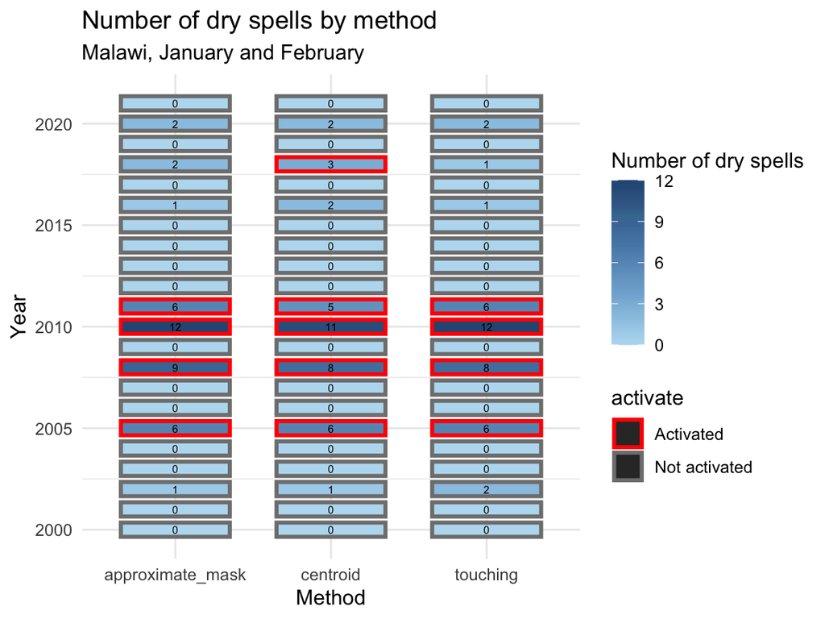

We can see that our years of activation are the same in all methods, except that we wouldn’t activate in 2018 unless we are using the centroid method.

## Areas with different dry spells

Most of the differences come from Zomba City, except in 2018.

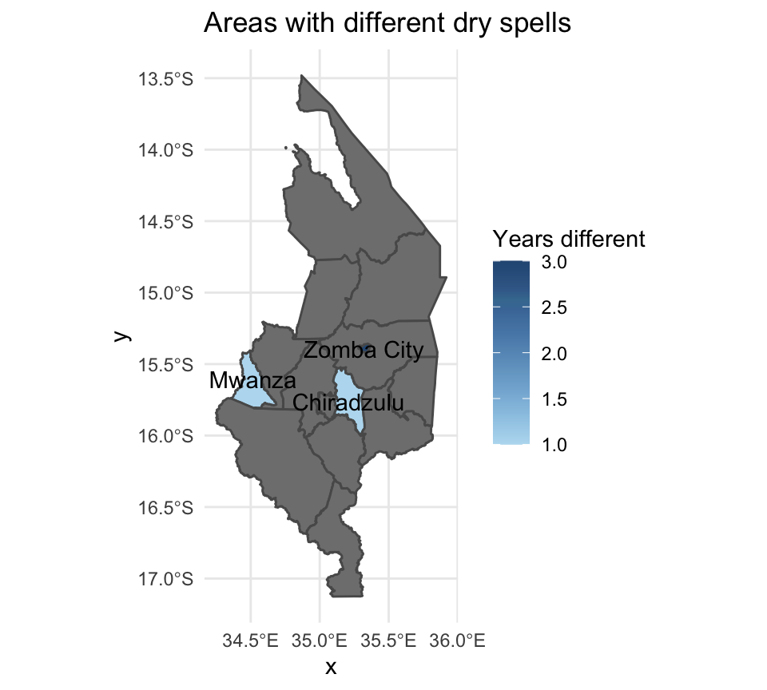

| ADM2_EN | year | method |
| --- | --- | --- |
| Chiradzulu | 2018 | approximate_mask, centroid |
| Mwanza | 2018 | centroid |
| Zomba City | 2008 | approximate_mask |
| Zomba City | 2010 | approximate_mask, touching |
| Zomba City | 2011 | approximate_mask, touching |

## Raster-based dry spells

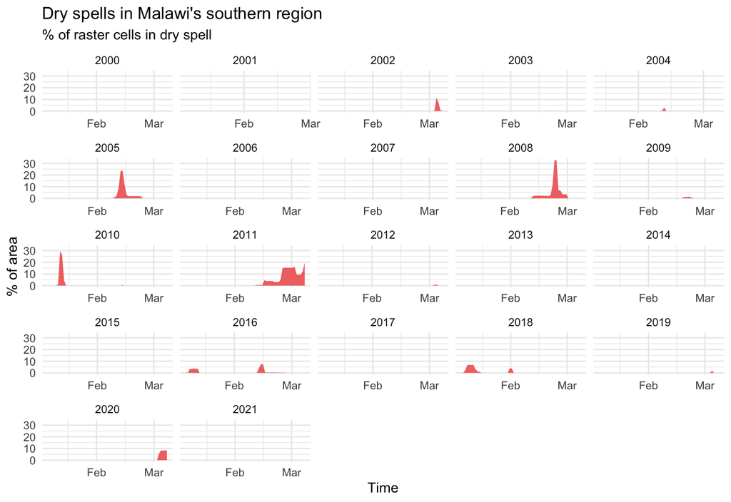

## Raster-based dry spells vs. admin

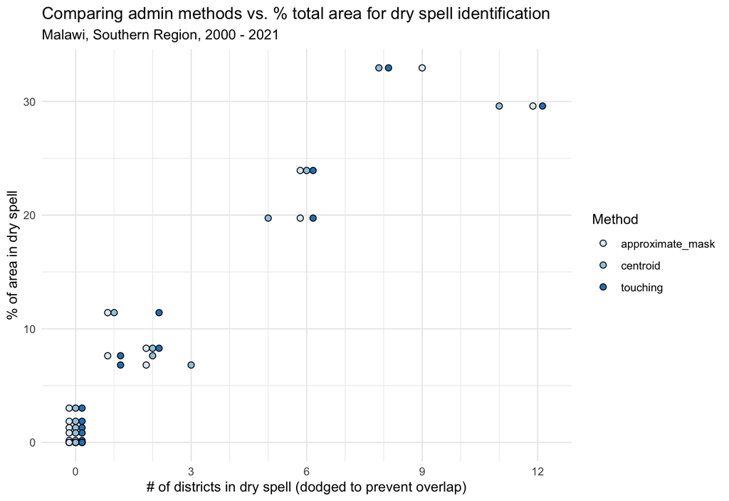

## Raster-based dry spells vs. admin

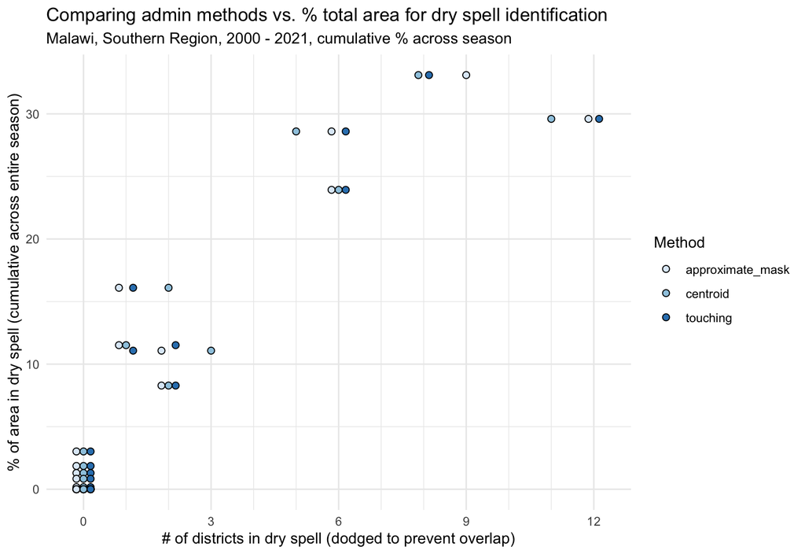

## Raster-based dry spells vs. admin

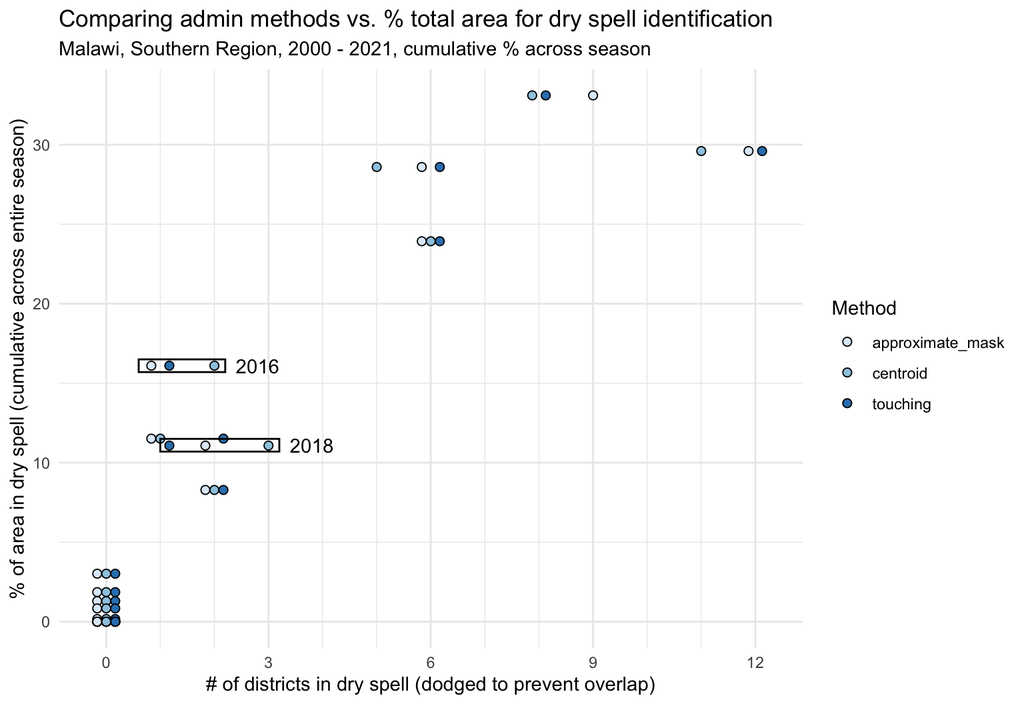

## Compare years

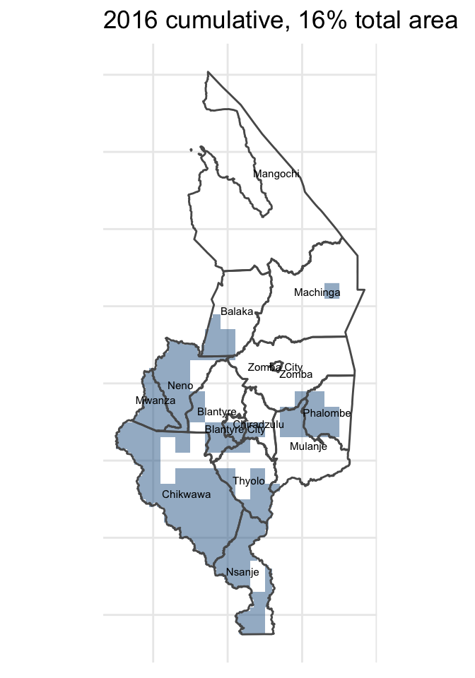

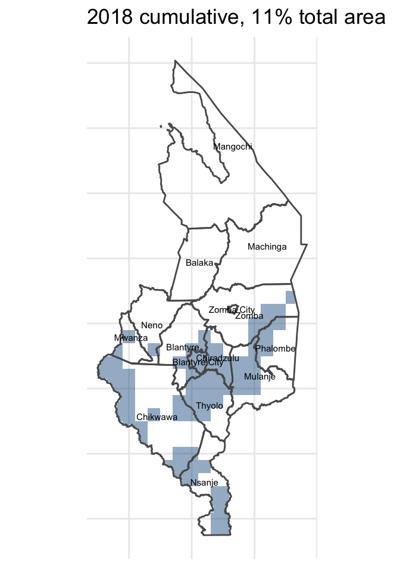

## Precipitation comparisons

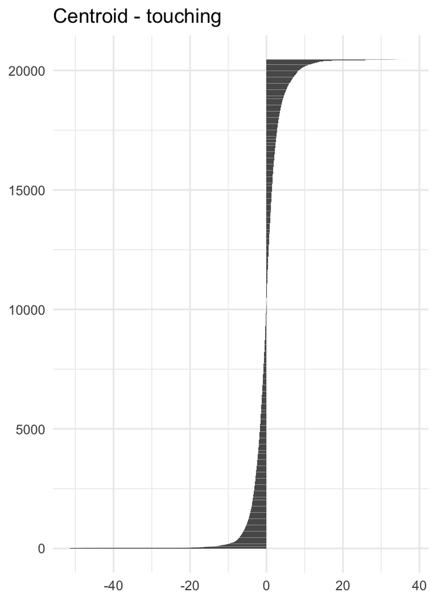

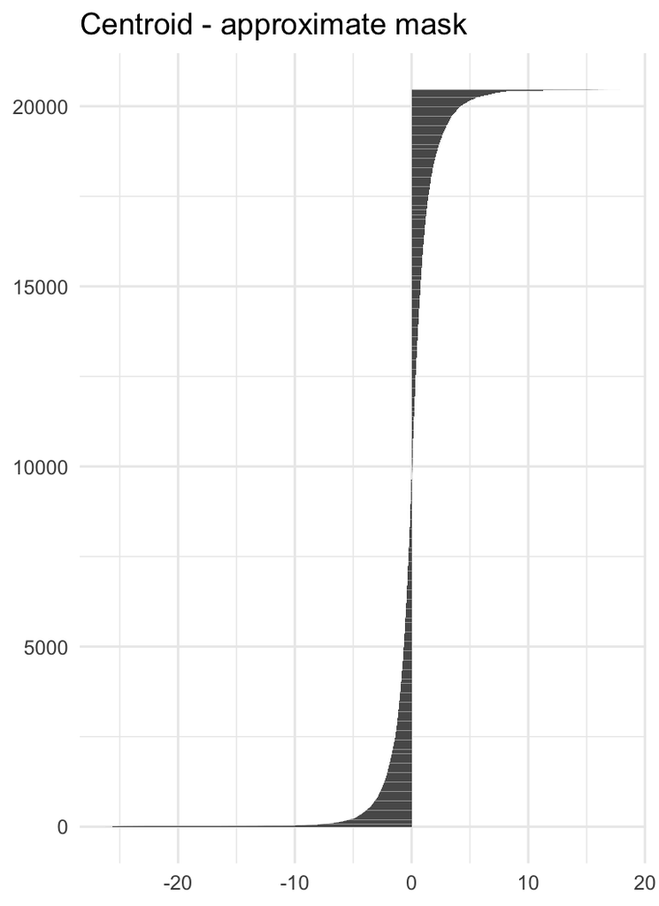

## Conclusions

Our choice of aggregation method doesn’t matter when we have extremely high geographic spread of of dry spells across the region. However, at lower prevalence of geographic spread, the choice has a large (and often random) impact on number of districts with dry spells observed.